# README

## Optimal Budget Allocation Approach to Regional Tuberculosis and HIV Care Delivery Programs Considering Equity, Effectiveness, and Uncertainty

### Contents in the repository:

1. About the Approach
2. Description of Parameter Files
3. Descriptions of Model Execution Files
4. Description of Results Files

### About the Approach

This repositiory contains the files needed to run an optimal budget allocation approach to regional TB and HIV care delivery programs in South Africa. The dynamic transmission model and optimization was programmed in R version 3.5.2 and the system of differential equations was solved with the deSolve package. I ran the code on Hyak, the University of Washington’s supercomputing system, to allow for computations at scale.

Disease progression is modeled with a dynamic transmission model in the nine South African provinces under facility-based and community-based care delivery programs. Model uncertainties in disease progression are considered by identifying a range of parameter sets that meet calibration targets. Model projections are used to quantify health outcomes and program costs used in a multi-objective optimization approach. The approach minimizes two objectives representing inequities in TB- and HIV-related mortality rates between regions and total TB- and HIV-related deaths. A given budget constrains the total program costs. A set of Pareto optimal solutions with sufficient statistical evidence that they satisfy the budget constraint and are non-dominated is returned.

#### Illustration of Transitions used in the Dynamic Transmission Model to Describe TB and HIV Disease Drogression

**TB Transitions**

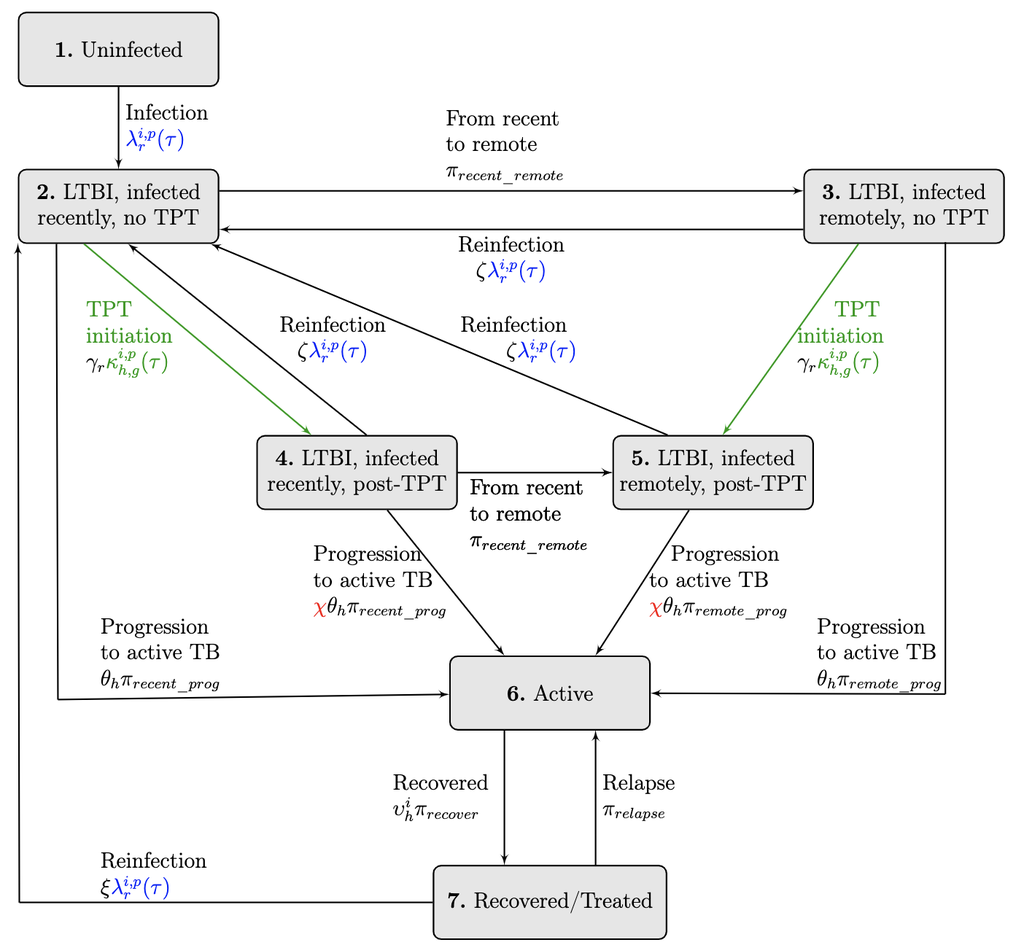

**HIV Transitions**

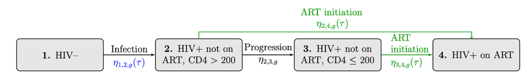

Above is an illustration of the rates of flow for the TB and HIV dynamic transmission model. Rates of flow between each compartment are governed by differential equations, as described in the appendix. Differential equations govern rates of flow between each compartment. Each tuberculosis (TB) compartment is stratified across two TB drug-resistance compartments, four human immunodeficiency virus (HIV) compartments, and two genders. The latent TB infection (LTBI) compartment is distinguished by those infected within two years, considered recent, and more than two years, considered remote. Individuals can age into TB compartments 1 (uninfected), 2 and 3 (LTBI, recent and remote, no TPT), and 6 (active TB), and HIV compartments 1 (HIV–) and 2 (HIV+, not on ART, CD4 > 200). Individuals can age out or die from any compartment. TB preventative therapy (TPT) initiations are highlighted in green to emphasize that care delivery programs directly impact them. TB force of infection is highlighted in blue to indicate the care delivery program indirectly impact them.

#### Example Illustration of Pareto Optimal Solutions Returned by the Multi-Objective Optimization Approach

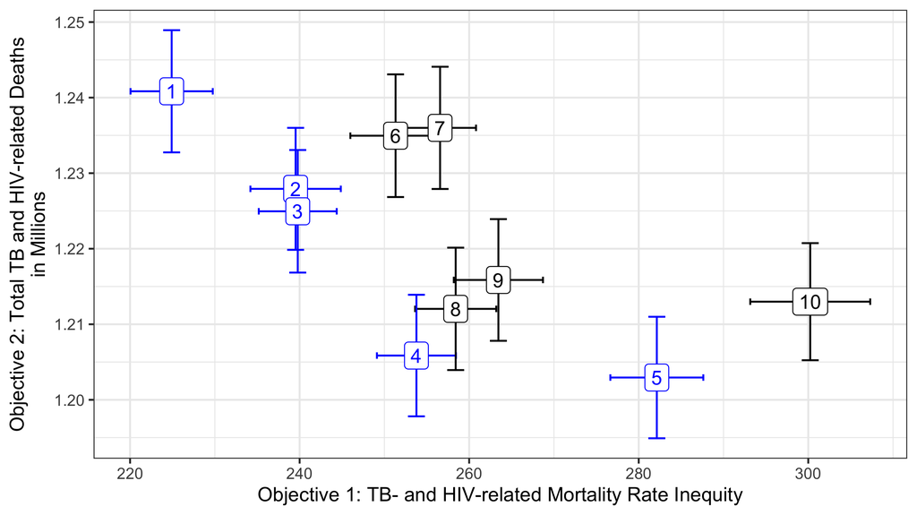

Illustration of the trade-offs of ten Pareto optimal solutions, including the sample means and 95% confidence intervals for the two objectives. Solutions 1-5 are highlighted in blue to indicate that these solutions are non-dominated if we only consider the sample means of the objective functions. Solutions 6-10 are also included because they are non-dominated when considering 95% confidence intervals of the objective functions.